# Interesting Inferences

## Setup

### Loading the Required Packages

The initial step involves loading the required packages in Rstudio to perform statistical analysis. The three packages used for this project are **ggplot2**,**dplyr** and **statsr**. The **ggplot2**, **dplyr** and **statsr** packages are used for **data visualization**, **data wrangling** and **executing statistical functions** respectively. The chunk of code below performs the function of loading the required packages for further analysis.

```r
library(ggplot2)
library(dplyr)
library(statsr)
```

### Loading the Data

The subsequent step is to load the data required for analysis. This is achieved by the **load(“brfss2013.RData”)** command.The data set contains **491775** observations and **330** variables. The variables are a combination of numerical and categorical variables. The dimensions of the dataset can are obtained by the command **dim(brfss2013.RData)**. The following chunk of code performs the function of loading the dataset and obtaining the dimensions of the dataset.

```r
load("brfss2013.RData")
dim(brfss2013)
```

```
## [1] 491775    330
```

## Part 1: Data

The Behavioral Risk Factor Surveillance System (BRFSS) is a collaborative project between all of the states in the United States (US) and participating US territories and the Centers for Disease Control and Prevention (CDC). BRFSS is an ongoing surveillance system designed to measure behavioral risk factors for the non-institutionalized adult population (18 years of age and older) residing in the US. The BRFSS was initiated in 1984, with 15 states collecting surveillance data on risk behaviors through monthly telephone interviews. Over time, the number of states participating in the survey increased; by 2001, 50 states, the District of Columbia, Puerto Rico, Guam, and the US Virgin Islands were participating in the BRFSS. Today, all 50 states, the District of Columbia, Puerto Rico, and Guam collect data annually and American Samoa, Federated States of Micronesia, and Palau collect survey data over a limited point- in-time (usually one to three months). BRFSS collects data from more than 400,000 adult interviews each year. The data from BRFSS for the year 2013 was used for analysis in this project.

As the interviews were conducted all over the US and the large quantum of data points in the dataset one might think that the observations drawn from the dataset can be inferred for the entire US adult population. On careful investigation of the dataset we can find out that the percentage of data obtained from each US state and territory is not commensurate to its population. For instance **California** and **Texas** which are the most populous states in the US contribute to **12.14%** and **8.688%** of the US population respectively. However the states of California and Texas represent only **2.34%** and **2.22%** of the data points in the BRFSS dataset for 2013. The data set contains a large chunk of data points from states like **Florida**, **Kansas** and **Nebraska**. Hence the dataset is not weighted proportionally to the relative population of each state and territory. Hence the generalizability of the inferences derived from this dataset on the entire adult population in the US adults is debatable. For the purpose of this project it is assumed that the inferences drawn from this dataset can be generalized to include the entire adult population in the US for the year 2013.

According to the BRFSS website the interviews are **conducted randomly** while maintaining **anonymity between the individuals**. Hence there is **no bias** between amongst the individulas while collecting the data. The interviews are also **almost uniformly distributed** throughout the year. The dataset adequately represents the **male and female genders**. (The transgender category is not identified in this dataset) and people from the **age groups of 18-80**. The case can be treated as a **case of random sampling** and hence **causal inferences drawn from this dataset can be generalized to the entire US adult population (Male & Female, across all age groups) for the year 2013**.

## Part 2: Research questions

**Research question 1:**

The motivation behind this research question is to determine the effects of the number of adults in a household on the general health of the adult.

**Are people who are living alone less healthy than people living with other adults in their household?**

**What are the effects on the health of the person as the number of adults in the household increases?**

**Do the obtained inferences change for the number of adult men and adult women?**

**Variables of Interest:**

**Explanatory variables**:- number of adults in the household (numerical) `(numadult)`, number of adult men in the household (numerical) `(nummen)` and number of adult women in the household (numerical) `(numwomen)`

**Response variable**:- general health of the adult(categorical-Excellent, Very Good, Good, Fair or Poor) `(genhlth)`

This research question is of interest since many health magazines and blogs suggest that the general physical health of an individual living alone is worse than a person living in a household with many adults. These claims can be investigated from the BRFSS 2013 data set to substantiate or challenge these claims.

**Research question 2:**

Many medical journals and articles claim that diabetes increases the risk of developing high blood pressure. The validity of these claims can be checked through the BRFSS 2013 data set. This question can be of importance for the general society since the knowledge of the correlation between the occurence of diabetes and high blood pressure can help diabetic people make certain dietary changes and adopt precautionary measures to avoid the occurence of high blood pressure. The important questions to be answered in this section are as follows-

**Does diabetes increase the risk of high blood pressure?**

**Are the observed effects similar for diabetic men and women?**

**Variables of Interest:**

**Response variable**:- Occurence of High Blood Pressure (Categorical- Yes, No, Not Sure, Yes but during pregnany, NA) `(bphigh4)`

**Research question 3:**

Inadequate sleep is often correlated with reduced congnitive abilities such as memory and concentration. The purpose of this research question is to analyze whether reduced sleeping times increase the chances of reduced cognitive abilities such as memory and concentration. Secondly, are the observed effects uniform for both men and women. The important questions to be answered in this research question are given below-

**Does sleeping time have a direct correlation with the cognitive function such as memory and concentration?**

**Is the observed effect similar for both male and female groups?**

**Variables of Interest:**

**Explanatory variables**:- Sleeping time in hours over a 24 hour duration (Categorical - 0 to 24, NA ) `(sleptim1)`, Gender (Categorical Variable - M, F) `(SEX)`

**Response variable**:- Problem indecision making, concentration and memory (Categorical- Yes, No, NA) `(decide)`

## Part 3: Exploratory data analysis

**Research question 1:**

The initial part of the analysis for this research question involves filtering the dataset for relevant information to answer the research question. The number of adults in a household range from 1 to 45 (including NA values) in the data set. However **99.96%** of the data points lie between the values of **1 to 6**. A new data set `num_adults` is obtained using the filter function which negates the extreme outliers and filters out the NA values. This is accomplished by running the below chunk of code:-

```r
num_adults <- brfss2013 %>%
filter(numadult == 1|numadult == 2|numadult == 3|numadult== 4|numadult == 5|numadult ==6)
```

The next part of the analysis involves the plotting of the general health `(genhlth)` of the individuals as a function of the number of adults in the household. A bar graph is obtained using the `ggplot` function and by executing the subsequent chunk of code.

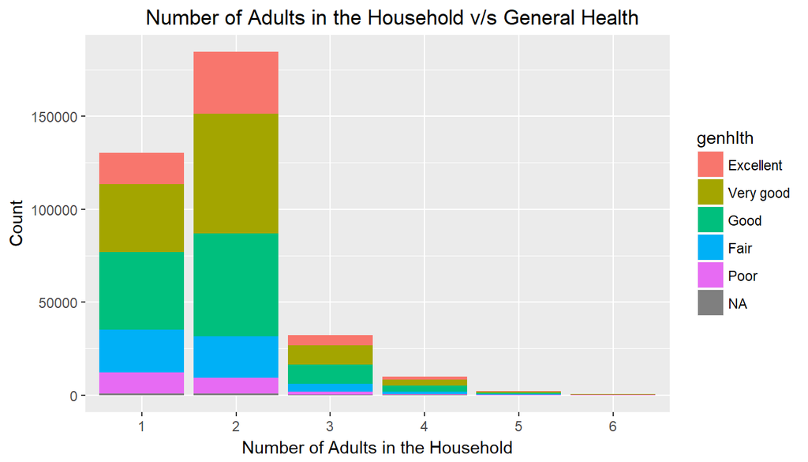

```r
ggplot(data = num_adults, aes(x = numadult, fill = genhlth)) +
geom_bar()+xlab("Number of Adults in the Household")+ylab("Count")+ggtitle("          Number of Adults in the Household v/s General Health")
```

The subsequent section involves the inspection on whether the obtained results in the above graph are similar for the number of adult men and women in the household. The relation between the number of adult men in the household and the general health of the individual is visualized by a bar graph similar to the first plot.

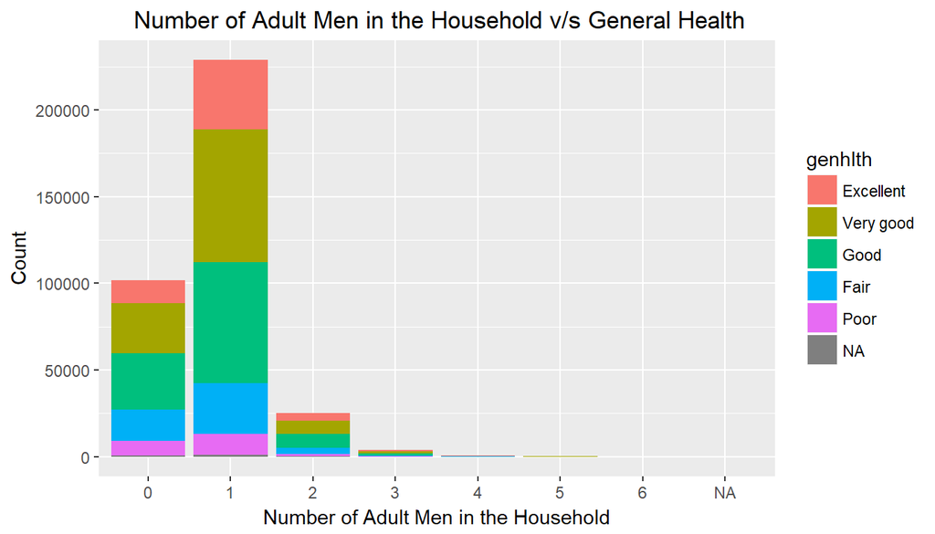

```r
ggplot(data = num_adults, aes(x = nummen, fill = genhlth)) +
geom_bar()+xlab("Number of Adult Men in the Household")+ylab("Count")+ggtitle("     Number of Adult Men in the Household v/s General Health")
```

Similarly, the effect of the number of women in the household on the general health of the individuals is obtained using a bar graph.

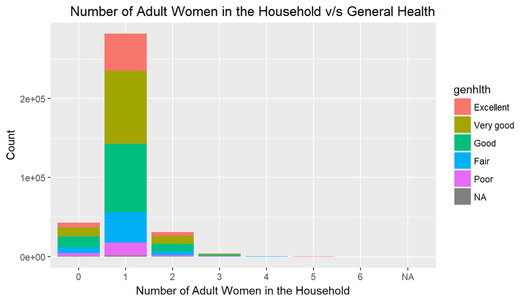

```r
ggplot(data = num_adults, aes(x = numwomen, fill = genhlth)) +
geom_bar()+xlab("Number of Adult Women in the Household")+ylab("Count")+ggtitle("     Number of Adult Women in the Household v/s General Health")
```

From the the above two figures it is clear that the obtained **results** do not have any **gender bias**. It can be inferred from the first figure that there is an **increase** in the number of people with **Excellent, Very Good and Good** health as the **number of adults in the household increases** from **1 to 2**. Hence it can be inferred that **individuals not living alone have a higher likelihood of being healthy than individuals living alone**.

The result for a **higher number of adults** is **unclear** from the earlier data visualization exercise due to the relative scarcity of these data points. A **numerical approach** using **summary statistics** is used to **analyze these data points**. we define a new parameter termed as **Health-rate** which is basically the fraction of individuals in each group which have do not have poor general health. The first step in the calculation of the Health-rate is to filter out the data points which have an NA value for the general health variable `(genhlth)`. This is achieved using the **filter function**. The Health rate is calculated using the **summarise function** and the results are arranged in the **descending order of the number of adults** in the household using the **arrange function**. The code chunk given below performs these functions.

```r
num_adults %>%
filter(! is.na(genhlth)) %>%
group_by(numadult) %>%
summarise(Health_rate = 1-(sum(genhlth == "Poor") / n())) %>%
arrange(desc(numadult))
```

```
## # A tibble: 6 x 2
##   numadult Health_rate
##   <fct>          <dbl>
## 1 6              0.928
## 2 5              0.941
## 3 4              0.951
## 4 3              0.946
## 5 2              0.953
## 6 1              0.913
```

The above table indicates that there is certainly an **increase in the likelihood of the individual having good general health as the number of adults increases from 1 to 2**. However, from **2 to 5 the results remain fairly constant** hence an **increase in the number of adults in the household beyond 2 does not improve** the **likelihood** of the **individual having a good health**. On the **contrary** there is a **dip** in the **health-rate** as the **number of adults in the household** increases to **6**. This can be attributed to the **decrease in the per capita availability of essential resources** as the **size of the household increases**.

As a subsequent exercise let us examine the effect of the size of the household on the likelihood of the individual having an Excellent health. A new paramter called **Excellent_Health** which is the fraction of individuals in each group having Excellent General Health is computed. The below code chunk performs the function of calculating this parameter.

```r
num_adults %>%
filter(! is.na(genhlth)) %>%
group_by(numadult) %>%
summarise(Excellent_Health = sum(genhlth == "Excellent") / n()) %>%
arrange(desc(numadult))
```

```
## # A tibble: 6 x 2
##   numadult Excellent_Health
##   <fct>               <dbl>
## 1 6                   0.146
## 2 5                   0.196
## 3 4                   0.187
## 4 3                   0.169
## 5 2                   0.182
## 6 1                   0.131
```

The obtained **results** are **similar** to the **earlier case** which substantiates the earlier inferences.

The **subsequent section** performs a **similar analysis** involving the computation of the **Health_rate** and **Excellent_Health** factors as a function of the **number of adult women** in the family.

```r
num_adult_women <- num_adults %>%
filter(numwomen ==0|numwomen == 1|numwomen == 2|numwomen == 3|numwomen== 4|numwomen == 5|numwomen ==6)
```

```r
num_adult_women %>%
filter(! is.na(genhlth)) %>%
group_by(numwomen) %>%
summarise(Health_rate = 1-(sum(genhlth == "Poor") / n())) %>%
arrange(desc(numwomen))
```

```
## # A tibble: 7 x 2
##   numwomen Health_rate
##   <fct>          <dbl>
## 1 6              0.667
## 2 5              0.909
## 3 4              0.945
## 4 3              0.943
## 5 2              0.941
## 6 1              0.941
## 7 0              0.910
```

**Similar results** as the **earlier case** except that there is a **larger dip** in the **Health_rate** as the number of **adult_women** in the household **increases to 6**.

```r
num_adult_women %>%
filter(! is.na(genhlth)) %>%
group_by(numwomen) %>%
summarise(Excellent_Health = sum(genhlth == "Excellent") / n()) %>%
arrange(desc(numwomen))
```

```
## # A tibble: 7 x 2
##   numwomen Excellent_Health
##   <fct>               <dbl>
## 1 6                   0
## 2 5                   0.145
## 3 4                   0.171
## 4 3                   0.163
## 5 2                   0.163
## 6 1                   0.166
## 7 0                   0.138
```

The obtained results are **similar** to the **initial analysis** except that there is a **larger dip** when the number of **adult women in the household** increases to **6**.

An **identical analysis** involving the calculation of the **Health_rate** and **Excellent_Health** parameters as a function of the **number of adult men in the household** is performed. The subsequent code chunk is used for this purpose.

```r
num_adult_men <- num_adults %>%
filter(nummen == 0|nummen == 1|nummen == 2|nummen == 3|nummen== 4|nummen == 5|nummen ==6)
```

```r
num_adult_men %>%
filter(! is.na(genhlth)) %>%
group_by(nummen) %>%
summarise(Health_rate = 1-(sum(genhlth == "Poor") / n())) %>%
arrange(desc(nummen))
```

```
## # A tibble: 7 x 2
##   nummen Health_rate
##   <fct>        <dbl>
## 1 6            1
## 2 5            0.957
## 3 4            0.940
## 4 3            0.944
## 5 2            0.943
## 6 1            0.947
## 7 0            0.915
```

```r
num_adult_men %>%
filter(! is.na(genhlth)) %>%
group_by(nummen) %>%
summarise(Excellent_Health = sum(genhlth == "Excellent") / n()) %>%
arrange(desc(nummen))
```

```
## # A tibble: 7 x 2
##   nummen Excellent_Health
##   <fct>             <dbl>
## 1 6                0.25
## 2 5                0.0851
## 3 4                0.230
## 4 3                0.190
## 5 2                0.175
## 6 1                0.175
## 7 0                0.130
```

**Individuals living alone are less likely to be healthier than individuals living in a household with other adults**. The **obtained results** are **similar** to the **analysis** conducted for **women** except that there is an **increase** in the **Health-rate** and **Excellent_health factors** when the number of **adult men** in the household **increases to 6**. This is an **outlier** due to the **scarcity** in the **number of data points** having the number of **men in the household as well as the number of adults in the household as 6**.The rest of the data points observe a similar trend and hence it can be concluded that the **obtained results are free of any gender bias except for higher outlier values**. Further analysis would be required to investigate the inferences of these outlier values which is beyond the scope of this project.

**Research question 2:**

The first step involved in the analysis of this research question involves the formation of a new data set comprising of people who have diabetes using the filter function. The new dataset is labeled as `diab`.

```r
diab <- brfss2013 %>%
filter(diabete3 == "Yes")
```

As a next step we would like to obtain the count of the number of diabteic people who are diabetic and hypertension or borderline hypertension. This is obtained using summarise function and by executing the following code.

```r
diab %>%
filter(!is.na(bphigh4)) %>%
group_by(bphigh4) %>%
summarise(count=n())
```

```
## # A tibble: 4 x 2
##   bphigh4                                    count
##   <fct>                                      <int>
## 1 Yes                                        47176
## 2 Yes, but female told only during pregnancy   216
## 3 No                                         14400
## 4 Told borderline or pre-hypertensive          406
```

In order to prove the causality between the occurence of hypertension amongst diabetic people it is imperative to prove that the percentage of non-diabetic people suffereing from hypertension is significantly lower than **75.848%**. Hence a similar analysis is performed for non-diabetic people and the results are summarized below:-

```r
brfss2013 %>%
filter(!is.na(bphigh4),diabete3 == "No") %>%
group_by(bphigh4) %>%
summarise(count=n())
```

```
## # A tibble: 4 x 2
##   bphigh4                                     count
##   <fct>                                       <int>
## 1 Yes                                        144738
## 2 Yes, but female told only during pregnancy   3052
## 3 No                                         262162
## 4 Told borderline or pre-hypertensive          4313
```

About **35.98%** of the **non-diabetic population** suffers from hypertension or borderline hypertension which is **significantly lower** than the **75.848%** of the **diabetic population** which suffers from **hypertension or borderline hypertension**. Hence it can be inferred that **diabetic people** have a **higher risk of occurence of hypertension**.

The **following section** involves the **verification** that there is **no gender bias** in the **obtained results**. Hence a **similar analysis** is performed for **diabteic men** and **diabetic women** respectively.

```r
diab %>%
filter(!is.na(bphigh4),sex == "Female") %>%
group_by(bphigh4) %>%
summarise(count=n())
```

```
## # A tibble: 4 x 2
##   bphigh4                                    count
##   <fct>                                      <int>
## 1 Yes                                        27347
## 2 Yes, but female told only during pregnancy   212
## 3 No                                          8128
## 4 Told borderline or pre-hypertensive          188
```

**76.75%** of the **diabetic women** surveyed are **hypertensive** or **borderline hypertensive**.

```r
brfss2013 %>%
filter(!is.na(bphigh4),diabete3 == "No",sex == "Female") %>%
group_by(bphigh4) %>%
summarise(count=n())
```

```
## # A tibble: 4 x 2
##   bphigh4                                     count
##   <fct>                                       <int>
## 1 Yes                                         83845
## 2 Yes, but female told only during pregnancy   3028
## 3 No                                         154974
## 4 Told borderline or pre-hypertensive          1873
```

**35.17%** of the **non-diabetic women** surveyed are **hypertensive** or **borderline hypertensive**.

```r
diab %>%
filter(!is.na(bphigh4),bphigh4 != "Yes, but female told only during pregnancy",sex == "Male") %>%
group_by(bphigh4) %>%
summarise(count=n())
```

```
## # A tibble: 3 x 2
##   bphigh4                             count
##   <fct>                               <int>
## 1 Yes                                 19829
## 2 No                                   6272
## 3 Told borderline or pre-hypertensive   218
```

**76.169%** of the **diabetic men** surveyed are **hypertensive** or **borderline hypertensive**.

```r
brfss2013 %>%
filter(!is.na(bphigh4),diabete3 == "No",bphigh4 != "Yes, but female told only during pregnancy",sex == "Male") %>%
group_by(bphigh4) %>%
summarise(count=n())
```

```
## # A tibble: 3 x 2
##   bphigh4                              count
##   <fct>                                <int>
## 1 Yes                                  60893
## 2 No                                  107187
## 3 Told borderline or pre-hypertensive   2440
```

```r
diabetic_data <- data.frame(
    group = c("Diabetic", "Diabetic-Women", "Diabetic-Men" , "Non-Diabetic", "Non-Diabetic-Women","Non-Diabetic-Men"),
    group_name= c("A", "B", "C" , "D", "E","F"),
    Percentage_hypertensive = c(75.848, 76.75, 76.169, 35.98, 35.17, 35.71)
    )
diabetic_data
```

```
##                group group_name Percentage_hypertensive
## 1           Diabetic          A                  75.848
## 2     Diabetic-Women          B                  76.750
## 3       Diabetic-Men          C                  76.169
## 4       Non-Diabetic          D                  35.980
## 5 Non-Diabetic-Women          E                  35.170
## 6   Non-Diabetic-Men          F                  35.710
```

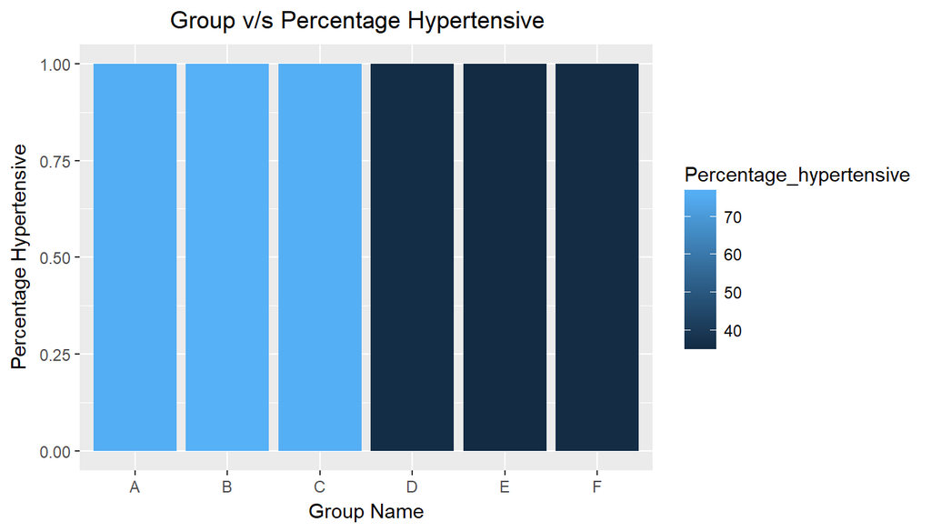

```r
ggplot(data = diabetic_data, aes(x = group_name, fill = Percentage_hypertensive )) +
geom_bar()+xlab("Group Name")+ylab("Percentage Hypertensive")+ggtitle("             Group v/s Percentage Hypertensive")
```

The **results** obtained for both **male** and **female** groups **closely synchronise** with each other. Hence there is **no gender bias** in the results. In conclusion **diabetic people** are at a **significantly greater risk** of **becoming hypertensive**. Furthermore, the **risk** is **equally high** amongst **diabetic males and females**.

**Research question 3:**

The **fundamental aim of this research question** is to **study the effect of the sleeping time each day** on the **cognitive abilities** such as **memory and concentration of the individual**. The **sleeping time** takes **discrete values from 0 to 24** but the values from **0 to 2** and **13 to 248** seem **impractical** and about **98.9%** of the **data points** lie within the range of **3 to 12 hours**. Hence the **data set** is filtered to obtain the values with a sleeping time of **3 to 12 hours**. The **filtered dataset** is stored as `sleep_adults`.

```r
sleep_adults <- brfss2013 %>%
filter(sleptim1 == 3|sleptim1 == 4|sleptim1 == 5|sleptim1 == 6|sleptim1 == 7|sleptim1 == 8|sleptim1 == 9|sleptim1 == 10|sleptim1 == 11|sleptim1 == 12)
```

As a fundamental analysis it would be interesting to obtain the **summary statistics of the sleeping times** of the entire dataset. This is obtained using the **summarise function**.

```r
sleep_adults %>%
filter(!is.na(sleptim1),!sleptim1==0) %>%
summarise(mean_st = mean(sleptim1), median_st=median(sleptim1),iqr_st=IQR(sleptim1),sd_st = sd(sleptim1), n = n())
```

```
##    mean_st median_st iqr_st    sd_st      n
## 1 7.035064         7      2 1.347505 481371
```

Interestingly the **mean and the median values are almost equal**. Hence the **distribution of sleeping times** might follow a **normal distribution** centered around **7 hours**.

As a subsequent part of the analysis the sleeping time for `the sleep_adults` dataset is plotted as a function of gender.

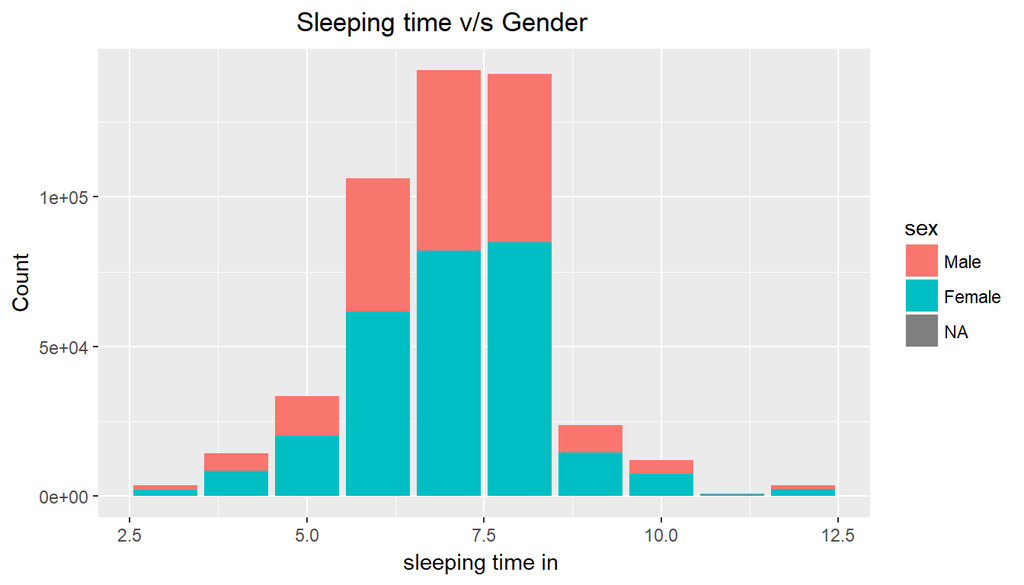

```r
ggplot(data = sleep_adults, aes(x = sleptim1, fill = sex)) +
geom_bar()+xlab("sleeping time in ")+ylab("Count")+ggtitle("                          Sleeping time v/s Gender")
```

There **does not appear** to be a significant **gender bias** in the dataset. But a **summary statistics analysis** on the **sleeping times of men and women** would confirm this fact.

```r
sleep_adults %>%
filter(!is.na(sleptim1),!sleptim1==0,sex == "Female") %>%
summarise(mean_st_female = mean(sleptim1), median_st_female=median(sleptim1),iqr_st_female=IQR(sleptim1),sd_st_female = sd(sleptim1), n = n())
```

```
##   mean_st_female median_st_female iqr_st_female sd_st_female      n
## 1       7.047696                7             2     1.360924 283693
```

```r
sleep_adults %>%
filter(!is.na(sleptim1),!sleptim1==0,sex == "Male") %>%
summarise(mean_st_male = mean(sleptim1), median_st_male=median(sleptim1),iqr_st_male=IQR(sleptim1),sd_st_male = sd(sleptim1), n = n())
```

```
##   mean_st_male median_st_male iqr_st_male sd_st_male      n
## 1     7.016932              7           2   1.327806 197677
```

The **summary statistics for the sleeping times** of **men and women** are almost similar with the **same median and interquartile range** and **almost equal mean and standard deviation values**. Hence **this proves that there is no gender bias in the distribution of sleeping times amongst males and females**. Hence the effects of **sleeping times on the cognitive abilities of individuals** can be analyzed on the **entire dataset independent of gender**.

The categorical variable `decide` in the dataset specifies whether the given individual has a problem in cognitive functions such as memory, concentration and decision making. The categorical variable sleeping time is plotted as a function of sleeping time.

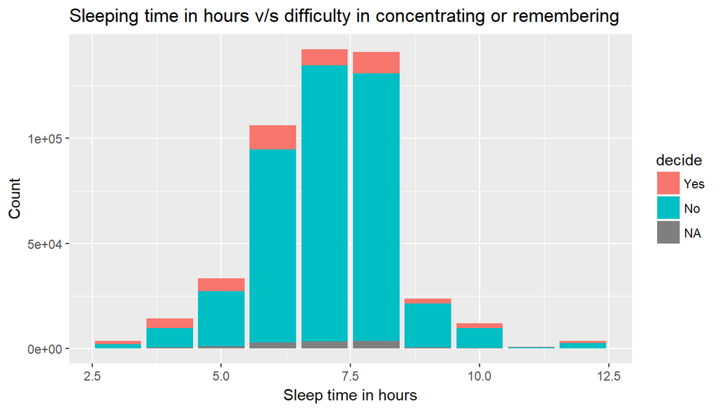

```r
ggplot(data = sleep_adults, aes(x = sleptim1, fill = decide)) +
geom_bar()+xlab("Sleep time in hours")+ylab("Count")+ggtitle("Sleeping time in hours v/s difficulty in concentrating or remembering ")
```

As a part of the summary statistical analysis the **sleeping times** are **divided** into **groups of two**. The **group A** represents the **individuals** with **sleeping times** of **3 or 4 hours**.

```r
sleep_adults %>%
filter(sleptim1 == 3|sleptim1==4) %>%
group_by(decide) %>%
summarise(count=n())
```

```
## # A tibble: 3 x 2
##   decide count
##   <fct>  <int>
## 1 Yes     5863
## 2 No     11305
## 3 <NA>     589
```

**34.15%** of the people in **group A** have **cognitive issues**.

The **group B** represents the **individuals** with **sleeping times** of **5 or 6 hours**.

```r
sleep_adults %>%
filter(sleptim1 == 5|sleptim1==6) %>%
group_by(decide) %>%
summarise(count=n())
```

```
## # A tibble: 3 x 2
##   decide  count
##   <fct>   <int>
## 1 Yes     17721
## 2 No     118252
## 3 <NA>     3660
```

**13.0327%** of the people in **group B** have **cognitive issues**.

The **group C** represents the **individuals** with **sleeping times** of **7 or 8 hours**.

```r
sleep_adults %>%
filter(sleptim1 == 7|sleptim1==8) %>%
group_by(decide) %>%
summarise(count=n())
```

```
## # A tibble: 3 x 2
##   decide  count
##   <fct>   <int>
## 1 Yes     17956
## 2 No     258658
## 3 <NA>     6957
```

The **group D** represents the **individuals** with **sleeping times** of **9 or 10 hours**.

```r
sleep_adults %>%
filter(sleptim1 == 9|sleptim1==10) %>%
group_by(decide) %>%
summarise(count=n())
```

```
## # A tibble: 3 x 2
##   decide count
##   <fct>  <int>
## 1 Yes     4840
## 2 No     30114
## 3 <NA>     948
```

The **group E** represents the **individuals** with **sleeping times** of **11 or 12 hours**.

```r
sleep_adults %>%
filter(sleptim1 == 11|sleptim1==12) %>%
group_by(decide) %>%
summarise(count=n())
```

```
## # A tibble: 3 x 2
##   decide count
##   <fct>  <int>
## 1 Yes     1336
## 2 No      3022
## 3 <NA>     150
```

```r
sleep_data <- data.frame(
    Sleep_group = c("A", "B", "C" , "D", "E"),
    Sleeping_time = c(" 3 or 4 hours ", " 5 or 6 hours ", " 7 or 8 hours "," 9 or 10 hours "," 11 or 12 hours "),
    Problem_mem_conc_percent = c(34.15, 13.0327, 6.4913561, 13.8467, 30.65)
    )
sleep_data
```

```
##   Sleep_group    Sleeping_time Problem_mem_conc_percent
## 1           A    3 or 4 hours                 34.150000
## 2           B    5 or 6 hours                 13.032700
## 3           C    7 or 8 hours                  6.491356
## 4           D   9 or 10 hours                 13.846700
## 5           E  11 or 12 hours                 30.650000
```

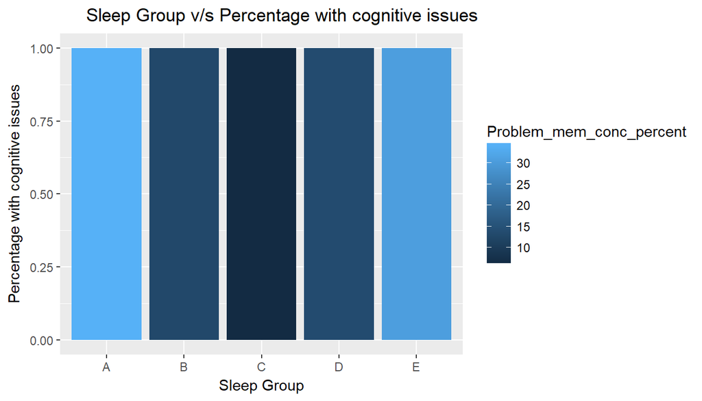

```r
ggplot(data = sleep_data, aes(x = Sleep_group, fill = Problem_mem_conc_percent  )) +
geom_bar()+xlab("Sleep Group")+ylab("Percentage with cognitive issues")+ggtitle("     Sleep Group v/s Percentage with cognitive issues")
```

In summary the **distribution of sleep times for men and women are almost similar** with equal mean and median values which might be **indicative of a normal distribution variation**. Moreover, **the percentage of people with cognitive issues decreases with an increase in sleeping time upto 8 hours**. **Above 8 hours of sleeping time the percentage of people with cognitive issues again increases**. Hence the **optimum sleeping time** to avoid cognitive issus would be **7 to 8 hours** for both men and women**.

[output not shown]